# Corbin Carroll vs Ketel Marte (Statcast / StatAPI)

## Home Run Pitch Location (Strike Zone)

Color = launch speed, Size = launch angle

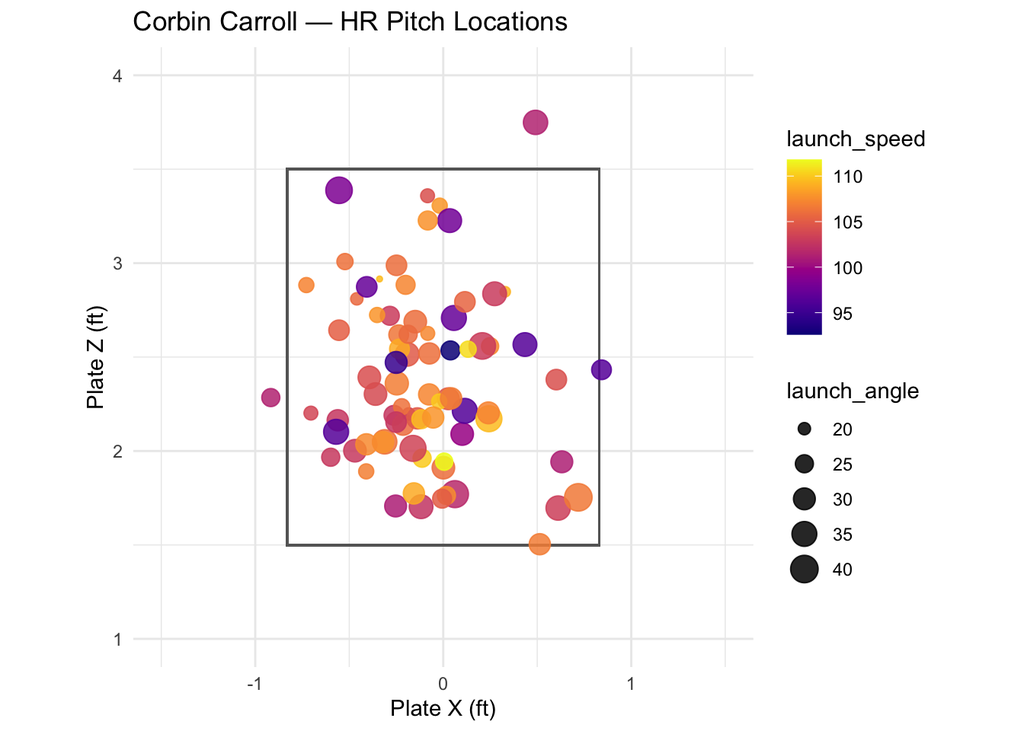

```r
plot_hr_zone <- function(df, title) {

  d <- df %>%
    filter(eventType == "home_run") %>%
    transmute(
      plate_x = plate_x_last,
      plate_z = plate_z_last,
      launch_speed = launch_speed,
      launch_angle = launch_angle
    ) %>%
    filter(is.finite(plate_x), is.finite(plate_z))

  ggplot(d, aes(plate_x, plate_z)) +
    geom_rect(
      xmin = -0.83, xmax = 0.83,
      ymin = 1.5, ymax = 3.5,
      fill = NA, color = "grey40"
    ) +
    geom_point(aes(color = launch_speed, size = launch_angle),
               alpha = 0.85) +
    scale_color_viridis(option = "C") +
    coord_equal(xlim = c(-1.5, 1.5), ylim = c(1, 4)) +
    labs(title = title, x = "Plate X (ft)", y = "Plate Z (ft)") +
    theme_minimal()
}

plot_hr_zone(Corbin_HR, "Corbin Carroll — HR Pitch Locations")
```

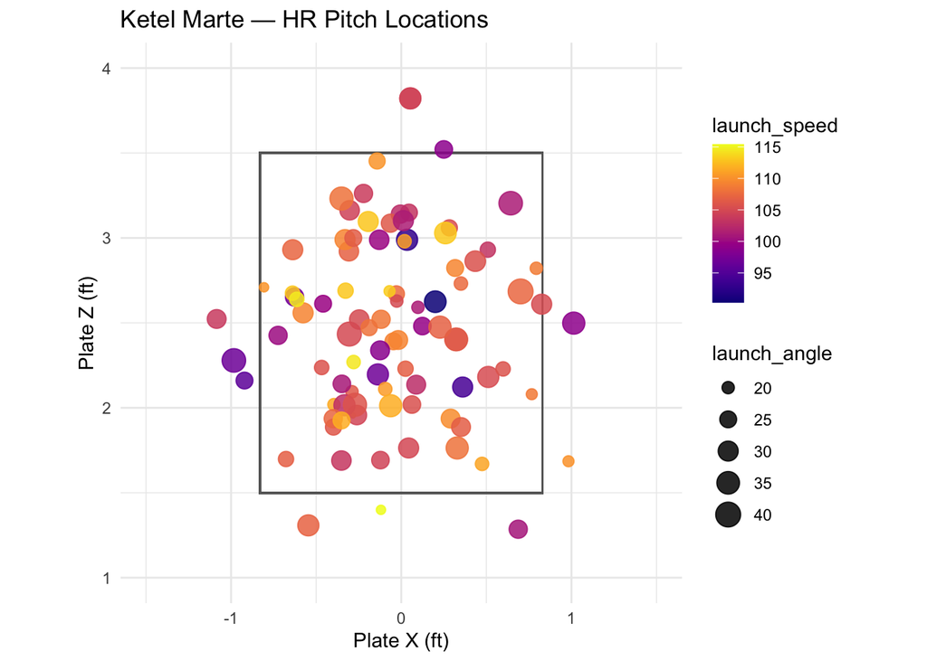

```r
plot_hr_zone(Ketel_HR,  "Ketel Marte — HR Pitch Locations")
```

```r
bind_rows(
  Corbin_HR %>% mutate(player = "Corbin Carroll"),
  Ketel_HR  %>% mutate(player = "Ketel Marte")
) %>%
  group_by(player) %>%
  summarise(
    HRs = n(),
    avg_launch_speed = mean(launch_speed, na.rm = TRUE),
    sd_launch_speed  = sd(launch_speed, na.rm = TRUE),
    avg_launch_angle = mean(launch_angle, na.rm = TRUE),
    sd_launch_angle  = sd(launch_angle, na.rm = TRUE),
    .groups = "drop"
  )
```

```
## # A tibble: 2 × 6
##   player   HRs avg_launch_speed sd_launch_speed avg_launch_angle sd_launch_angle
##   <chr>  <int>            <dbl>           <dbl>            <dbl>           <dbl>
## 1 Corbi…    78             105.            4.04             28.4            4.99
## 2 Ketel…    91             106.            5.00             27.1            5.23
```

These visualizations compare home-run pitch locations and batted-ball characteristics for Corbin Carroll and Ketel Marte. Color reflects launch speed, point size reflects launch angle, and the strike zone provides spatial context.

Taken together, Carroll fits an efficiency-driven power profile built on repeatable mechanics and tight pitch selection, while Marte profiles as a more versatile power threat who can generate damage across more pitch heights and locations. From a strategic standpoint, Carroll is more sensitive to pitch location, whereas Marte is harder to neutralize without relying on pitch mix and sequencing in addition to location.

## 3×3 Strike-Zone HR Distribution

Because Corbin Carroll’s HR pitch locations appeared **concentrated in the lower-to-middle portion** of the strike zone, a 3×3 grid was introduced to **quantify zone-level differences** and enable a clearer comparison with Ketel Marte.

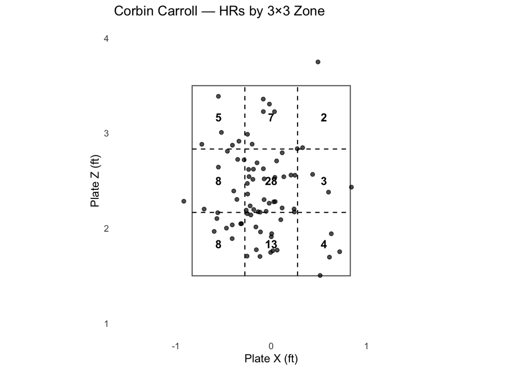

```r
plot_hr_zone_3x3 <- function(df, title) {

  d <- df %>%
    filter(eventType == "home_run") %>%
    transmute(plate_x = plate_x_last, plate_z = plate_z_last) %>%
    filter(is.finite(plate_x), is.finite(plate_z))

  zl <- -0.83; zr <- 0.83; zb <- 1.5; zt <- 3.5
  x1 <- zl + (zr - zl) / 3; x2 <- zl + 2 * (zr - zl) / 3
  z1 <- zb + (zt - zb) / 3; z2 <- zb + 2 * (zt - zb) / 3

  d <- d %>%
    mutate(
      col = case_when(plate_x < x1 ~ 1L, plate_x < x2 ~ 2L, TRUE ~ 3L),
      row = case_when(plate_z < z1 ~ 1L, plate_z < z2 ~ 2L, TRUE ~ 3L),
      zone = (row - 1) * 3 + col
    )

  counts <- d %>% count(zone)

  centers <- expand_grid(row = 1:3, col = 1:3) %>%
    mutate(
      zone = (row - 1) * 3 + col,
      x = zl + (col - 0.5) * (zr - zl) / 3,
      y = zb + (row - 0.5) * (zt - zb) / 3
    ) %>%
    left_join(counts, by = "zone") %>%
    mutate(n = if_else(is.na(n), 0L, n))

  ggplot(d, aes(plate_x, plate_z)) +
    annotate("rect", xmin = zl, xmax = zr, ymin = zb, ymax = zt,
             fill = NA, color = "grey40") +
    annotate("segment", x = x1, xend = x1, y = zb, yend = zt, linetype = "dashed") +
    annotate("segment", x = x2, xend = x2, y = zb, yend = zt, linetype = "dashed") +
    annotate("segment", x = zl, xend = zr, y = z1, yend = z1, linetype = "dashed") +
    annotate("segment", x = zl, xend = zr, y = z2, yend = z2, linetype = "dashed") +
    geom_point(alpha = 0.7) +
    geom_text(data = centers, aes(x, y, label = n),
              inherit.aes = FALSE, fontface = "bold") +
    coord_equal(xlim = c(-1.5, 1.5), ylim = c(1, 4)) +
    labs(title = title, x = "Plate X (ft)", y = "Plate Z (ft)") +
    theme_minimal() +
    theme(panel.grid = element_blank())
}

plot_hr_zone_3x3(Corbin_HR, "Corbin Carroll — HRs by 3×3 Zone")
```

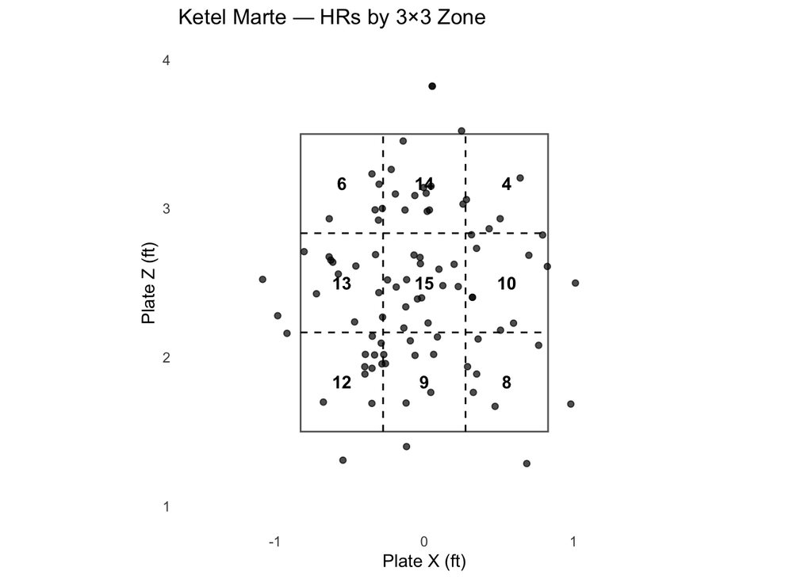

```r
plot_hr_zone_3x3(Ketel_HR,  "Ketel Marte — HRs by 3×3 Zone")
```

Corbin Carroll — 3×3 HR Distribution

- Carroll’s home runs are heavily concentrated in the center of the strike zone. The middle–middle zone accounts for the largest share (28 HRs), with the lower–middle zone as a clear secondary area (13 HRs). Very little damage comes from the upper or outer parts of the zone, with almost no production up and away. Overall, his home runs cluster vertically in the middle–lower region, with limited reach to the edges.
- This pattern suggests that Carroll’s power is highly localized. He does most of his damage on pitches left in the heart of the zone, especially middle–down, consistent with a precision-driven profile built on optimized swing mechanics and selective pitch damage.

Ketel Marte — 3×3 HR Distribution

- Marte’s home runs are distributed more evenly across the strike zone. While the middle–middle zone remains the most productive, substantial damage also appears in the middle–inside and middle–outside zones, with additional power showing up both higher and lower in the zone.
- This distribution indicates a broader damage zone both horizontally and vertically. Marte is able to lift pitches on the inner and outer halves as well as in the middle, making his power less dependent on a single mistake location.

Overall, the 3×3 breakdown reinforces that Carroll’s power is concentrated in the middle–lower strike zone, reflecting an efficiency-driven and location-sensitive profile, whereas Marte produces home runs from a wider range of pitch locations, making him a more location-resistant power threat.

## Baseball & R&D Implications

Pitching Strategy

- Vs Carroll
  - Avoid middle–down misses.
  - Expanding vertically (especially up) reduces HR risk.
- Vs Marte
  - Location alone is insufficient.
  - Must rely on pitch mix, movement, and sequencing.

Player Evaluation

- Carroll:
  - Predictable, repeatable HR profile
  - Easier to model and game-plan against
- Marte:
  - Higher defensive and pitching complexity
  - Harder to neutralize due to spatial flexibility